# Final Project

- [County Socioeconomic Data](https://www.openintro.org/data/index.php?data=county_complete)
- [Crime Data](https://ucr.fbi.gov/crime-in-the-u.s/2017/crime-in-the-u.s.-2017)
- [FIPS table](https://github.com/kjhealy/fips-codes/blob/master/state_and_county_fips_master.csv)

Note that the CSV files used were slightly modified to exclude irrelevant data.

```r
data <- fread("../data/final_data.csv")

response <- c('unemployment_rate', 'crime_rate', 'median_household_income', 'poverty')
needed <- data %>% select(
        # VARS OF INTEREST
        hs_grad, some_college, bachelors,  # education stats
        # CONTROLS
        pop,  # population
        # demographics (races)
        black, native, asian, pac_isl, hispanic,
        white_not_hispanic, other_single_race, two_plus_races,
        # demographics (age)
        age_under_5, age_over_65, median_age,
        women_16_to_50_birth_rate,  # birth rate
        veterans,  # veteran % of pop
        computer,  # % w/ access to computer
        households, persons_per_household,  # pretty obvious
        # % of population that's uninsured & whatever
        uninsured, uninsured_age_under_6, uninsured_age_under_19, uninsured_age_over_74,
        civilian_labor_force,  # size of labor force
        all_of(response)
)

set.seed(SEED)

n <- nrow(needed)
train_size <- 2102
train_ind <- sample(n, train_size)
data_train <- needed[train_ind,]

inp_data <- data_train %>% select(-all_of(response))
data_test <- needed[-train_ind,]
data_val <- data_test[1:10,]
data_test <- data_test[-(1:10),]
```

Without further ado, let’s get started!

# Median Income

Since per capita income is so closely related to median household income, we decided to not do analysis for that.

## LASSO Selection

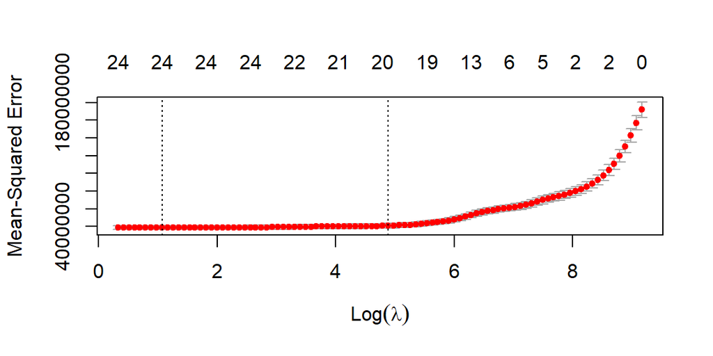

```r
income_y <- data_train$median_household_income
income_data <- inp_data
set.seed(SEED)
cv_res_income <- cv.glmnet(as.matrix(income_data), income_y)
plot(cv_res_income)
```

```r
coef_income <- coef(cv_res_income, s = "lambda.1se")  #s=c("lambda.1se","lambda.min") or lambda value
coef_income <- coef_income[which(coef_income != 0),]  # get the non=zero coefficients
good_vars <- names(coef_income)[-1]
income_data <- income_data %>%
        select(all_of(good_vars))
```

After this, we’re good to use `lm` on the remaining variables!

## Linear Regression & Significance

For significance analysis, we used a significance level of 5%.

```r
income_data$income <- data_train$median_household_income
fit_income <- lm(income ~ ., data = income_data)
summary(fit_income)
```

```
Call:
lm(formula = income ~ ., data = income_data)

Residuals:
   Min     1Q Median     3Q    Max
-45056  -3653   -275   3279  35445

Coefficients:
                               Estimate    Std. Error t value          Pr(>|t|)
(Intercept)               -111156.77417    4961.79028  -22.40           < 2e-16
hs_grad                       244.91845      44.74620    5.47 0.000000049443268
bachelors                     462.85176      27.82572   16.63           < 2e-16
black                           0.76949      26.18361    0.03           0.97656
native                        -79.37815      58.35528   -1.36           0.17390
asian                        1397.25685     167.71052    8.33           < 2e-16
pac_isl                     -3489.71645     775.78341   -4.50 0.000007226816687
hispanic                       59.09496      15.96562    3.70           0.00022
other_single_race             179.96920      86.25374    2.09           0.03705
two_plus_races               -117.63076     176.51274   -0.67           0.50522
age_under_5                  1376.65009     182.74399    7.53 0.000000000000073
age_over_65                 -1552.40202      82.96222  -18.71           < 2e-16
median_age                   1757.78474      72.45676   24.26           < 2e-16
women_16_to_50_birth_rate     238.02662      68.88579    3.46           0.00056
veterans                     -215.54077      65.55420   -3.29           0.00103
computer                      558.62882      34.72633   16.09           < 2e-16
households                     -0.00676       0.00132   -5.11 0.000000346849084
persons_per_household       14804.02466     841.92497   17.58           < 2e-16
uninsured                    -877.76898      58.96560  -14.89           < 2e-16
uninsured_age_under_6          34.05469      40.65449    0.84           0.40232
uninsured_age_under_19        551.35760      60.74559    9.08           < 2e-16

(Intercept)               ***
hs_grad                   ***
bachelors                 ***
black
native
asian                     ***
pac_isl                   ***
hispanic                  ***
other_single_race         *
two_plus_races
age_under_5               ***
age_over_65               ***
median_age                ***
women_16_to_50_birth_rate ***
veterans                  **
computer                  ***
households                ***
persons_per_household     ***
uninsured                 ***
uninsured_age_under_6
uninsured_age_under_19    ***
---
Signif. codes:  0 '***' 0.001 '**' 0.01 '*' 0.05 '.' 0.1 ' ' 1

Residual standard error: 6250 on 2081 degrees of freedom
Multiple R-squared:  0.776, Adjusted R-squared:  0.773
F-statistic:  360 on 20 and 2081 DF,  p-value: <2e-16
```

Here, we get rid of all the statistically insignificant variables one by one with backward selection.

```r
fit_income <- lm(income ~ . - black, data = income_data)
summary(fit_income)
```

```
Call:
lm(formula = income ~ . - black, data = income_data)

Residuals:
   Min     1Q Median     3Q    Max
-45058  -3653   -274   3284  35443

Coefficients:
                               Estimate    Std. Error t value          Pr(>|t|)
(Intercept)               -111121.82096    4815.97818  -23.07           < 2e-16
hs_grad                       244.82014      44.61028    5.49 0.000000045610175
bachelors                     462.98284      27.45931   16.86           < 2e-16
native                        -79.73380      57.07294   -1.40           0.16255
asian                        1397.61851     167.21826    8.36           < 2e-16
pac_isl                     -3490.36982     775.27869   -4.50 0.000007100767246
hispanic                       58.95688      15.25503    3.86           0.00011
other_single_race             180.11138      86.09729    2.09           0.03656
two_plus_races               -117.92189     176.19225   -0.67           0.50339
age_under_5                  1376.37333     182.45737    7.54 0.000000000000068
age_over_65                 -1552.60203      82.66275  -18.78           < 2e-16
median_age                   1757.67059      72.33520   24.30           < 2e-16
women_16_to_50_birth_rate     238.08060      68.84478    3.46           0.00055
veterans                     -215.33529      65.16463   -3.30           0.00097
computer                      558.37244      33.60463   16.62           < 2e-16
households                     -0.00676       0.00131   -5.14 0.000000302693562
persons_per_household       14804.16340     841.70970   17.59           < 2e-16
uninsured                    -877.22995      56.02695  -15.66           < 2e-16
uninsured_age_under_6          34.04324      40.64287    0.84           0.40234
uninsured_age_under_19        551.01575      59.60709    9.24           < 2e-16

(Intercept)               ***
hs_grad                   ***
bachelors                 ***
native
asian                     ***
pac_isl                   ***
hispanic                  ***
other_single_race         *
two_plus_races
age_under_5               ***
age_over_65               ***
median_age                ***
women_16_to_50_birth_rate ***
veterans                  ***
computer                  ***
households                ***
persons_per_household     ***
uninsured                 ***
uninsured_age_under_6
uninsured_age_under_19    ***
---
Signif. codes:  0 '***' 0.001 '**' 0.01 '*' 0.05 '.' 0.1 ' ' 1

Residual standard error: 6250 on 2082 degrees of freedom
Multiple R-squared:  0.776, Adjusted R-squared:  0.774
F-statistic:  379 on 19 and 2082 DF,  p-value: <2e-16
```

```r
fit_income <- lm(income ~ . - two_plus_races - black, data = income_data)
summary(fit_income)
```

```
Call:
lm(formula = income ~ . - two_plus_races - black, data = income_data)

Residuals:
   Min     1Q Median     3Q    Max
-45088  -3631   -267   3299  35321

Coefficients:
                               Estimate    Std. Error t value          Pr(>|t|)
(Intercept)               -111243.01032    4811.93511  -23.12           < 2e-16
hs_grad                       245.25622      44.59962    5.50 0.000000042868851
bachelors                     463.15807      27.45443   16.87           < 2e-16
native                        -89.38025      55.21569   -1.62           0.10565
asian                        1382.10190     165.58133    8.35           < 2e-16
pac_isl                     -3687.23738     717.21501   -5.14 0.000000298744430
hispanic                       58.95877      15.25301    3.87           0.00011
other_single_race             177.41701      85.99172    2.06           0.03922
age_under_5                  1381.82508     182.25129    7.58 0.000000000000051
age_over_65                 -1552.28794      82.65046  -18.78           < 2e-16
median_age                   1760.68787      72.18501   24.39           < 2e-16
women_16_to_50_birth_rate     239.81214      68.78703    3.49           0.00050
veterans                     -222.97325      64.14904   -3.48           0.00052
computer                      556.23446      33.44802   16.63           < 2e-16
households                     -0.00677       0.00131   -5.15 0.000000284813816
persons_per_household       14833.25559     840.47515   17.65           < 2e-16
uninsured                    -880.45213      55.81232  -15.78           < 2e-16
uninsured_age_under_6          33.52864      40.63021    0.83           0.40934
uninsured_age_under_19        552.43091      59.56168    9.27           < 2e-16

(Intercept)               ***
hs_grad                   ***
bachelors                 ***
native
asian                     ***
pac_isl                   ***
hispanic                  ***
other_single_race         *
age_under_5               ***
age_over_65               ***
median_age                ***
women_16_to_50_birth_rate ***
veterans                  ***
computer                  ***
households                ***
persons_per_household     ***
uninsured                 ***
uninsured_age_under_6
uninsured_age_under_19    ***
---
Signif. codes:  0 '***' 0.001 '**' 0.01 '*' 0.05 '.' 0.1 ' ' 1

Residual standard error: 6250 on 2083 degrees of freedom
Multiple R-squared:  0.776, Adjusted R-squared:  0.774
F-statistic:  400 on 18 and 2083 DF,  p-value: <2e-16
```

```r
fit_income <- lm(
        income ~ . - two_plus_races - black - uninsured_age_under_6,
        data = income_data
)
summary(fit_income)
```

```
Call:
lm(formula = income ~ . - two_plus_races - black - uninsured_age_under_6,
    data = income_data)

Residuals:
   Min     1Q Median     3Q    Max
-45091  -3680   -270   3283  35327

Coefficients:
                               Estimate    Std. Error t value          Pr(>|t|)
(Intercept)               -111219.80145    4811.48460  -23.12           < 2e-16
hs_grad                       246.83486      44.55516    5.54 0.000000034076621
bachelors                     461.75710      27.39979   16.85           < 2e-16
native                        -89.71584      55.20997   -1.62           0.10432
asian                        1385.52317     165.51675    8.37           < 2e-16
pac_isl                     -3694.62879     717.10418   -5.15 0.000000281782269
hispanic                       58.16349      15.22137    3.82           0.00014
other_single_race             178.99319      85.96392    2.08           0.03745
age_under_5                  1381.59217     182.23712    7.58 0.000000000000051
age_over_65                 -1553.30572      82.63493  -18.80           < 2e-16
median_age                   1759.89313      72.17306   24.38           < 2e-16
women_16_to_50_birth_rate     239.22930      68.77814    3.48           0.00052
veterans                     -221.48427      64.11875   -3.45           0.00056
computer                      555.43487      33.43142   16.61           < 2e-16
households                     -0.00676       0.00131   -5.14 0.000000293403560
persons_per_household       14831.20606     840.40715   17.65           < 2e-16
uninsured                    -885.00976      55.53413  -15.94           < 2e-16
uninsured_age_under_19        586.42800      43.01216   13.63           < 2e-16

(Intercept)               ***
hs_grad                   ***
bachelors                 ***
native
asian                     ***
pac_isl                   ***
hispanic                  ***
other_single_race         *
age_under_5               ***
age_over_65               ***
median_age                ***
women_16_to_50_birth_rate ***
veterans                  ***
computer                  ***
households                ***
persons_per_household     ***
uninsured                 ***
uninsured_age_under_19    ***
---
Signif. codes:  0 '***' 0.001 '**' 0.01 '*' 0.05 '.' 0.1 ' ' 1

Residual standard error: 6250 on 2084 degrees of freedom
Multiple R-squared:  0.775, Adjusted R-squared:  0.774
F-statistic:  423 on 17 and 2084 DF,  p-value: <2e-16
```

```r
fit_income <- lm(
        income ~ . - two_plus_races - black - uninsured_age_under_6 - native,
        data = income_data
)
summary(fit_income)
```

```
Call:
lm(formula = income ~ . - two_plus_races - black - uninsured_age_under_6 -
    native, data = income_data)

Residuals:
   Min     1Q Median     3Q    Max
-44609  -3702   -281   3293  35399

Coefficients:
                               Estimate    Std. Error t value         Pr(>|t|)
(Intercept)               -109798.72551    4733.20479  -23.20          < 2e-16
hs_grad                       226.91105      42.85181    5.30 0.00000013135604
bachelors                     460.75710      27.40365   16.81          < 2e-16
asian                        1387.02917     165.57926    8.38          < 2e-16
pac_isl                     -3685.71258     717.36526   -5.14 0.00000030378825
hispanic                       60.86556      15.13622    4.02 0.00005996681355
other_single_race             176.27892      85.98150    2.05          0.04047
age_under_5                  1357.71965     181.71547    7.47 0.00000000000012
age_over_65                 -1560.67266      82.54294  -18.91          < 2e-16
median_age                   1768.29229      72.01606   24.55          < 2e-16
women_16_to_50_birth_rate     234.62989      68.74691    3.41          0.00065
veterans                     -226.06169      64.08204   -3.53          0.00043
computer                      569.57455      32.29189   17.64          < 2e-16
households                     -0.00675       0.00131   -5.13 0.00000030865683
persons_per_household       14529.20462     819.92277   17.72          < 2e-16
uninsured                    -899.73221      54.81166  -16.41          < 2e-16
uninsured_age_under_19        584.28655      43.00888   13.59          < 2e-16

(Intercept)               ***
hs_grad                   ***
bachelors                 ***
asian                     ***
pac_isl                   ***
hispanic                  ***
other_single_race         *
age_under_5               ***
age_over_65               ***
median_age                ***
women_16_to_50_birth_rate ***
veterans                  ***
computer                  ***
households                ***
persons_per_household     ***
uninsured                 ***
uninsured_age_under_19    ***
---
Signif. codes:  0 '***' 0.001 '**' 0.01 '*' 0.05 '.' 0.1 ' ' 1

Residual standard error: 6250 on 2085 degrees of freedom
Multiple R-squared:  0.775, Adjusted R-squared:  0.773
F-statistic:  449 on 16 and 2085 DF,  p-value: <2e-16
```

After trimming the bad variables, we now have our final list!

```r
bad <- c('two_plus_races',
         'black',
         'uninsured_age_under_6',
         'native')
income_data <- income_data %>%
        select(-all_of(bad))
fit_income <- lm(income ~ ., data = income_data)
summary(fit_income)
```

```
Call:
lm(formula = income ~ ., data = income_data)

Residuals:
   Min     1Q Median     3Q    Max
-44609  -3702   -281   3293  35399

Coefficients:
                               Estimate    Std. Error t value         Pr(>|t|)
(Intercept)               -109798.72551    4733.20479  -23.20          < 2e-16
hs_grad                       226.91105      42.85181    5.30 0.00000013135604
bachelors                     460.75710      27.40365   16.81          < 2e-16
asian                        1387.02917     165.57926    8.38          < 2e-16
pac_isl                     -3685.71258     717.36526   -5.14 0.00000030378825
hispanic                       60.86556      15.13622    4.02 0.00005996681355
other_single_race             176.27892      85.98150    2.05          0.04047
age_under_5                  1357.71965     181.71547    7.47 0.00000000000012
age_over_65                 -1560.67266      82.54294  -18.91          < 2e-16
median_age                   1768.29229      72.01606   24.55          < 2e-16
women_16_to_50_birth_rate     234.62989      68.74691    3.41          0.00065
veterans                     -226.06169      64.08204   -3.53          0.00043
computer                      569.57455      32.29189   17.64          < 2e-16
households                     -0.00675       0.00131   -5.13 0.00000030865683
persons_per_household       14529.20462     819.92277   17.72          < 2e-16
uninsured                    -899.73221      54.81166  -16.41          < 2e-16
uninsured_age_under_19        584.28655      43.00888   13.59          < 2e-16

(Intercept)               ***
hs_grad                   ***
bachelors                 ***
asian                     ***
pac_isl                   ***
hispanic                  ***
other_single_race         *
age_under_5               ***
age_over_65               ***
median_age                ***
women_16_to_50_birth_rate ***
veterans                  ***
computer                  ***
households                ***
persons_per_household     ***
uninsured                 ***
uninsured_age_under_19    ***
---
Signif. codes:  0 '***' 0.001 '**' 0.01 '*' 0.05 '.' 0.1 ' ' 1

Residual standard error: 6250 on 2085 degrees of freedom
Multiple R-squared:  0.775, Adjusted R-squared:  0.773
F-statistic:  449 on 16 and 2085 DF,  p-value: <2e-16
```

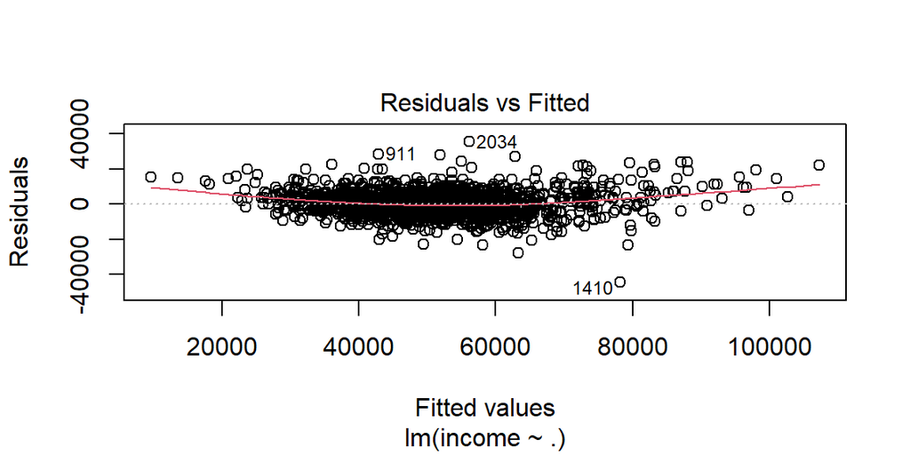

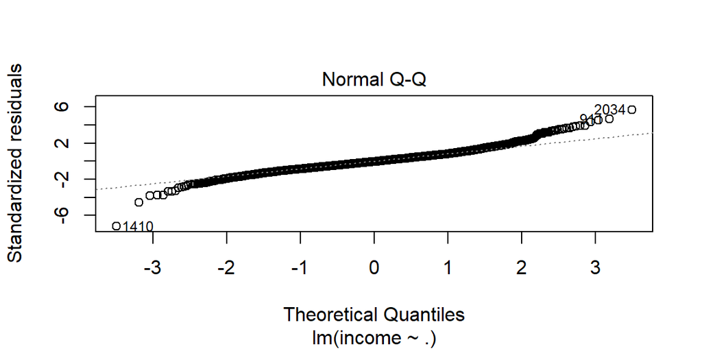

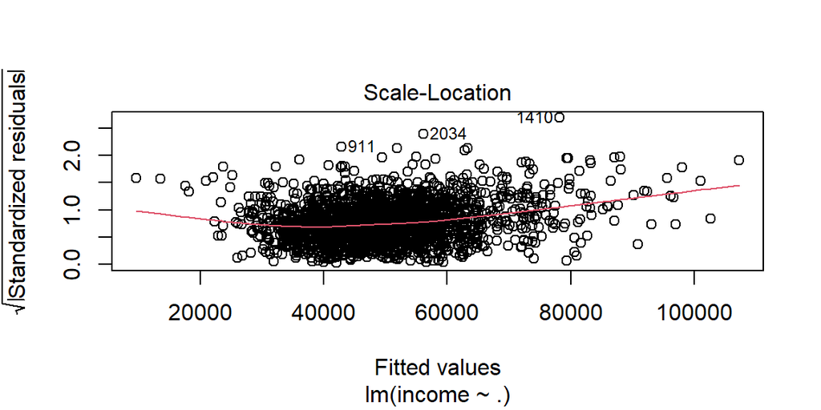

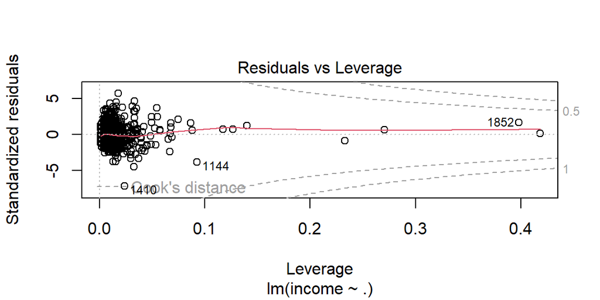

```r
plot(fit_income)
```

# Unemployment

## LASSO Selection

Basically the same stuff as before:

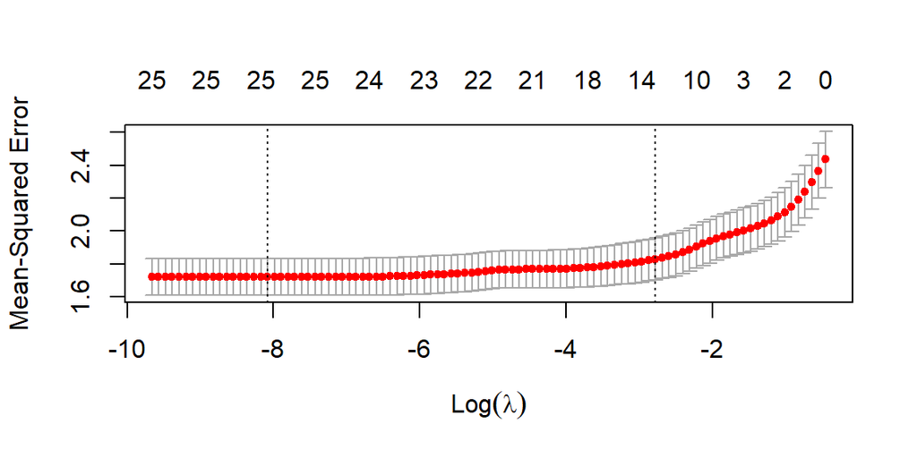

```r
unemp_data <- inp_data %>%
        mutate(rate = data_train$unemployment_rate)

Y <- as.matrix(unemp_data[, 26])  # 26 is the column with all the outputs
X <- as.matrix((unemp_data)[, -26])
set.seed(SEED)
cv_res_ue <- cv.glmnet(X, Y, alpha = 1, nfolds = 10)
plot(cv_res_ue)
```

This time, LASSO seemed to get rid of a *lot* more variables than before.

```r
coef_ue <- coef(cv_res_ue, s = "lambda.1se")  #s=c("lambda.1se","lambda.min") or lambda valu
coef(cv_res_ue, s = "lambda.1se")
```

```
26 x 1 sparse Matrix of class "dgCMatrix"
                                    s1
(Intercept)               13.103243218
hs_grad                   -0.051994530
some_college               .
bachelors                 -0.018002420
pop                        .
black                      0.006695995
native                     0.030161522
asian                      .
pac_isl                    .
hispanic                   .
white_not_hispanic        -0.007376620
other_single_race          .
two_plus_races             .
age_under_5               -0.103306354
age_over_65                .
median_age                 .
women_16_to_50_birth_rate -0.018895221
veterans                   0.032314409
computer                  -0.033335985
households                 0.000000136
persons_per_household      0.051957788
uninsured                  .
uninsured_age_under_6      .
uninsured_age_under_19    -0.024926415
uninsured_age_over_74      .
civilian_labor_force       .
```

```r
coef_ue <- coef_ue[which(coef_ue != 0),]  # get the non=zero coefficients
good_vars <- names(coef_ue)[-1]
unemp_data <- unemp_data %>%
        select(all_of(good_vars))
unemp_data <- unemp_data %>%
        mutate(rate = data_train$unemployment_rate)
```

## Linear Regression & Significance

It seems that `some_college` didn’t make the cut- interesting.  
Again, we’ll use `summary()` and `lm()` to get rid of all statistically insignificant variables.

```r
fit_ue2 <- lm(
        rate ~ .,
        unemp_data
)
summary(fit_ue2)
```

```
Call:
lm(formula = rate ~ ., data = unemp_data)

Residuals:
   Min     1Q Median     3Q    Max
-4.661 -0.802 -0.157  0.638 13.078

Coefficients:
                              Estimate   Std. Error t value         Pr(>|t|)
(Intercept)               13.393799523  0.772701151   17.33          < 2e-16
hs_grad                   -0.062679709  0.008727060   -7.18 0.00000000000095
bachelors                 -0.024285211  0.005463448   -4.45 0.00000924808084
black                      0.012907548  0.006294873    2.05           0.0404
native                     0.063109506  0.012211572    5.17 0.00000025911854
white_not_hispanic        -0.006590267  0.002751683   -2.39           0.0167
age_under_5               -0.194221366  0.032578620   -5.96 0.00000000292442
women_16_to_50_birth_rate -0.030775934  0.014370874   -2.14           0.0323
veterans                   0.068316298  0.012800008    5.34 0.00000010462037
computer                  -0.035101495  0.006978220   -5.03 0.00000053194150
households                 0.000000858  0.000000266    3.23           0.0013
persons_per_household      0.522694134  0.164446253    3.18           0.0015
uninsured_age_under_19    -0.046803319  0.006311366   -7.42 0.00000000000017

(Intercept)               ***
hs_grad                   ***
bachelors                 ***
black                     *
native                    ***
white_not_hispanic        *
age_under_5               ***
women_16_to_50_birth_rate *
veterans                  ***
computer                  ***
households                **
persons_per_household     **
uninsured_age_under_19    ***
---
Signif. codes:  0 '***' 0.001 '**' 0.01 '*' 0.05 '.' 0.1 ' ' 1

Residual standard error: 1.32 on 2089 degrees of freedom
Multiple R-squared:  0.287, Adjusted R-squared:  0.283
F-statistic: 70.2 on 12 and 2089 DF,  p-value: <2e-16
```

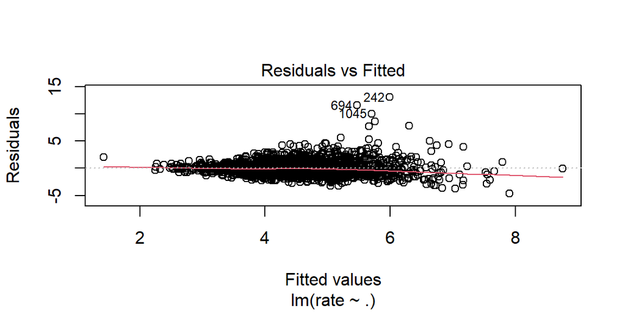

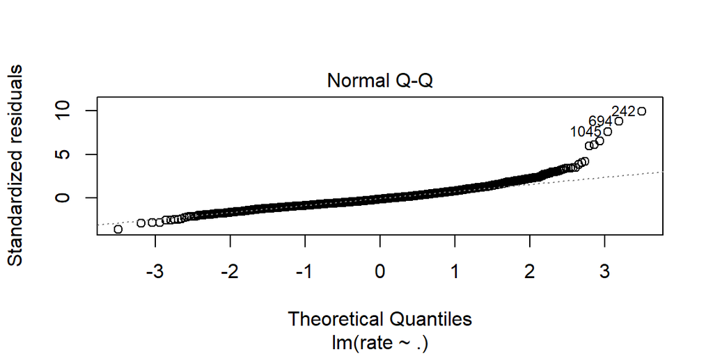

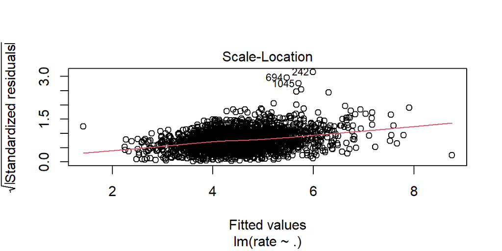

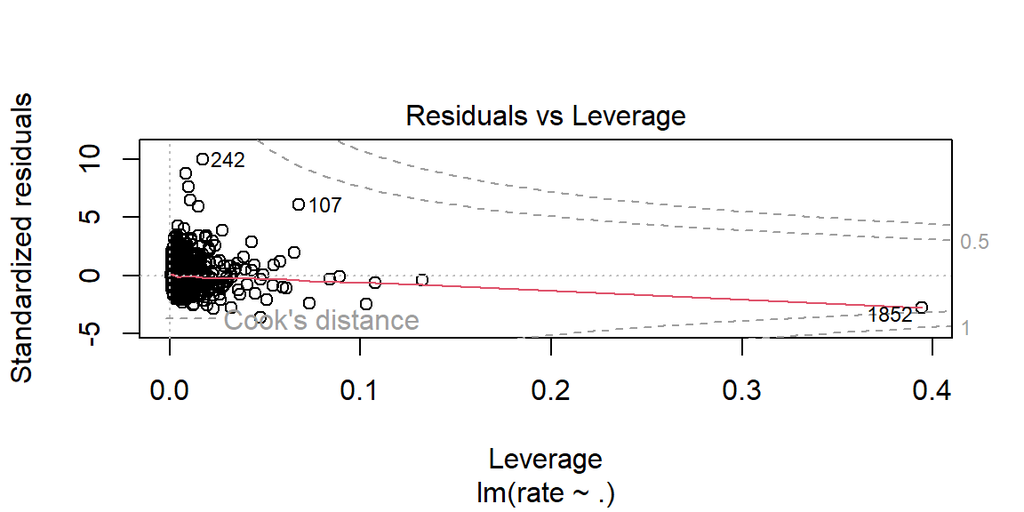

```r
plot(fit_ue2)
```

The thing is, this time it seems there were no insignificant variables.

For unemployment only, we will be testing our model with our testing data. We will use this to determine our error.

```r
set.seed(SEED)
predvals <- predict(fit_ue2, data_test)
rmse <- sqrt(mean((data_test$unemployment_rate - predvals)^2))
rmse
```

```
[1] 1.32
```

Our RMSE is 1.32, which is lower than that of our Neural Network. This means that this is a better model, so we will use this to predict the unemployment rates for our validation data.

```r
set.seed(SEED)
predvals <- predict(fit_ue2, data_val)
validation <- data.frame(predvals, data_val$unemployment_rate)
validation
```

|  | predvals | data_val.unemployment_rate |
| --- | --- | --- |
| 1 | 4.31 | 3.99 |
| 2 | 7.05 | 7.66 |
| 3 | 4.05 | 3.91 |
| 4 | 4.93 | 3.98 |
| 5 | 5.27 | 4.79 |
| 6 | 3.46 | 3.23 |
| 7 | 5.58 | 4.16 |
| 8 | 5.12 | 4.17 |
| 9 | 5.44 | 5.46 |
| 10 | 4.41 | 3.25 |

As you can see, although it’s not exact, our model is pretty close and can predict unemployment rates.

# Poverty

```r
pov_data <- inp_data %>%
        mutate(pov = data_train$poverty)
```

## LASSO Selection

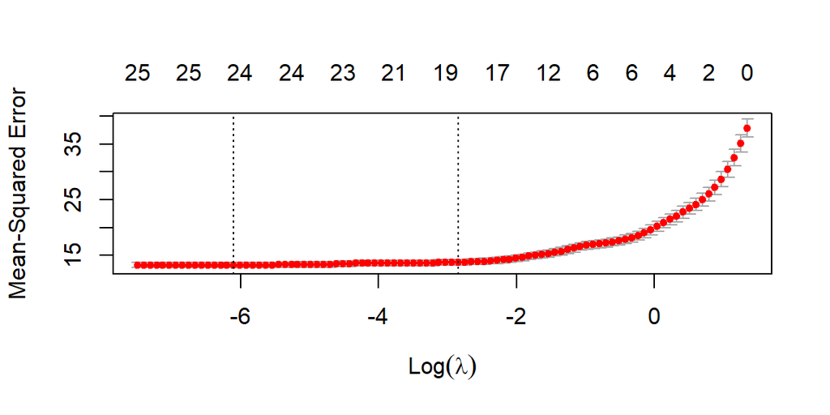

```r
y <- as.matrix(data_train$poverty)
X <- as.matrix(pov_data)[, -26]

set.seed(SEED)
cv_res_pov <- cv.glmnet(X, y, alpha = 1)
plot(cv_res_pov)
```

```r
coef_pov <- coef(cv_res_pov, s = "lambda.1se")  # s = c("lambda.1se","lambda.min") or lambda valu
coef_pov <- coef_pov[which(coef_pov != 0),]  # get the non=zero coefficients
good_vars <- names(coef_pov)[-1]
```

## Linear Regression & Significance

```r
total <- c("pov", good_vars)
# get a subset with response and LASSO output
pov_data <- pov_data[, ..total]
```

Now, we are ready to run `lm` with the updated `pov_data` from LASSO selection.

```r
fit_pov <- lm(pov ~ ., pov_data)
summary(fit_pov)
```

```
Call:
lm(formula = pov ~ ., data = pov_data)

Residuals:
    Min      1Q  Median      3Q     Max
-17.016  -2.119  -0.239   2.006  22.993

Coefficients:
                              Estimate   Std. Error t value        Pr(>|t|)
(Intercept)               100.01857676   2.74351420   36.46         < 2e-16 ***
hs_grad                    -0.36230336   0.02348443  -15.43         < 2e-16 ***
black                       0.09917345   0.01504763    6.59 0.0000000000553 ***
native                      0.35645600   0.03400348   10.48         < 2e-16 ***
asian                       0.09064492   0.09034494    1.00          0.3158
pac_isl                     0.42925005   0.44505616    0.96          0.3349
hispanic                   -0.06463216   0.00910630   -7.10 0.0000000000017 ***
other_single_race          -0.02482027   0.05011902   -0.50          0.6205
two_plus_races              0.05317543   0.10275527    0.52          0.6049
age_under_5                -0.55933288   0.10562902   -5.30 0.0000001313695 ***
age_over_65                 0.47280092   0.04831520    9.79         < 2e-16 ***
median_age                 -0.73354239   0.04215781  -17.40         < 2e-16 ***
women_16_to_50_birth_rate  -0.07883166   0.04005157   -1.97          0.0492 *
veterans                    0.11062250   0.03711771    2.98          0.0029 **
computer                   -0.28048719   0.01898007  -14.78         < 2e-16 ***
households                  0.00000174   0.00000077    2.26          0.0239 *
persons_per_household      -3.12159475   0.48984089   -6.37 0.0000000002280 ***
uninsured                   0.36740716   0.03419606   10.74         < 2e-16 ***
uninsured_age_under_19     -0.30511889   0.02606131  -11.71         < 2e-16 ***
uninsured_age_over_74       0.14891371   0.10878990    1.37          0.1712
---
Signif. codes:  0 '***' 0.001 '**' 0.01 '*' 0.05 '.' 0.1 ' ' 1

Residual standard error: 3.64 on 2082 degrees of freedom
Multiple R-squared:  0.655, Adjusted R-squared:  0.652
F-statistic:  208 on 19 and 2082 DF,  p-value: <2e-16
```

Again, we’ll get rid of all statistically insignificant variables through `summary()`.

```r
fit_pov <- lm(pov ~ . - other_single_race, pov_data)
summary(fit_pov)
```

```
Call:
lm(formula = pov ~ . - other_single_race, data = pov_data)

Residuals:
    Min      1Q  Median      3Q     Max
-17.028  -2.124  -0.237   2.001  22.985

Coefficients:
                              Estimate   Std. Error t value       Pr(>|t|)
(Intercept)               100.02212314   2.74300777   36.46        < 2e-16 ***
hs_grad                    -0.36187799   0.02346446  -15.42        < 2e-16 ***
black                       0.09884026   0.01502986    6.58 0.000000000061 ***
native                      0.35628933   0.03399565   10.48        < 2e-16 ***
asian                       0.08874370   0.09024698    0.98         0.3256
pac_isl                     0.43774266   0.44464507    0.98         0.3250
hispanic                   -0.06694519   0.00781586   -8.57        < 2e-16 ***
two_plus_races              0.05058870   0.10260383    0.49         0.6220
age_under_5                -0.56180408   0.10549196   -5.33 0.000000111486 ***
age_over_65                 0.47398380   0.04824738    9.82        < 2e-16 ***
median_age                 -0.73469666   0.04208571  -17.46        < 2e-16 ***
women_16_to_50_birth_rate  -0.07884000   0.04004431   -1.97         0.0491 *
veterans                    0.11121501   0.03709170    3.00         0.0027 **
computer                   -0.28074164   0.01896968  -14.80        < 2e-16 ***
households                  0.00000173   0.00000077    2.24         0.0249 *
persons_per_household      -3.11717587   0.48967088   -6.37 0.000000000238 ***
uninsured                   0.36791340   0.03417459   10.77        < 2e-16 ***
uninsured_age_under_19     -0.30515043   0.02605651  -11.71        < 2e-16 ***
uninsured_age_over_74       0.15182866   0.10861087    1.40         0.1623
---
Signif. codes:  0 '***' 0.001 '**' 0.01 '*' 0.05 '.' 0.1 ' ' 1

Residual standard error: 3.64 on 2083 degrees of freedom
Multiple R-squared:  0.655, Adjusted R-squared:  0.652
F-statistic:  219 on 18 and 2083 DF,  p-value: <2e-16
```

```r
fit_pov <- lm(pov ~ . - two_plus_races - other_single_race, pov_data)
summary(fit_pov)
```

```
Call:
lm(formula = pov ~ . - two_plus_races - other_single_race, data = pov_data)

Residuals:
   Min     1Q Median     3Q    Max
-17.03  -2.12  -0.25   2.01  23.00

Coefficients:
                               Estimate    Std. Error t value       Pr(>|t|)
(Intercept)               100.094699599   2.738557850   36.55        < 2e-16
hs_grad                    -0.362140683   0.023454150  -15.44        < 2e-16
black                       0.098430433   0.015004132    6.56 0.000000000068
native                      0.360243945   0.033029922   10.91        < 2e-16
asian                       0.095640278   0.089140208    1.07         0.2834
pac_isl                     0.521461530   0.410872757    1.27         0.2045
hispanic                   -0.066913036   0.007814169   -8.56        < 2e-16
age_under_5                -0.564185305   0.105362214   -5.35 0.000000095124
age_over_65                 0.473678823   0.048234652    9.82        < 2e-16
median_age                 -0.736005804   0.041994235  -17.53        < 2e-16
women_16_to_50_birth_rate  -0.079560938   0.040010335   -1.99         0.0469
veterans                    0.114593652   0.036446587    3.14         0.0017
computer                   -0.279962640   0.018900330  -14.81        < 2e-16
households                  0.000001736   0.000000769    2.26         0.0242
persons_per_household      -3.129891237   0.488902480   -6.40 0.000000000189
uninsured                   0.369525777   0.034011582   10.86        < 2e-16
uninsured_age_under_19     -0.305731957   0.026025078  -11.75        < 2e-16
uninsured_age_over_74       0.152125189   0.108589478    1.40         0.1614

(Intercept)               ***
hs_grad                   ***
black                     ***
native                    ***
asian
pac_isl
hispanic                  ***
age_under_5               ***
age_over_65               ***
median_age                ***
women_16_to_50_birth_rate *
veterans                  **
computer                  ***
households                *
persons_per_household     ***
uninsured                 ***
uninsured_age_under_19    ***
uninsured_age_over_74
---
Signif. codes:  0 '***' 0.001 '**' 0.01 '*' 0.05 '.' 0.1 ' ' 1

Residual standard error: 3.64 on 2084 degrees of freedom
Multiple R-squared:  0.655, Adjusted R-squared:  0.652
F-statistic:  232 on 17 and 2084 DF,  p-value: <2e-16
```

```r
fit_pov <- lm(pov ~ . - two_plus_races - other_single_race - asian, pov_data)
summary(fit_pov)
```

```
Call:
lm(formula = pov ~ . - two_plus_races - other_single_race - asian,
    data = pov_data)

Residuals:
    Min      1Q  Median      3Q     Max
-17.000  -2.128  -0.248   2.008  22.860

Coefficients:
                              Estimate   Std. Error t value       Pr(>|t|)
(Intercept)               99.802368379  2.725069022   36.62        < 2e-16 ***
hs_grad                   -0.361913980  0.023454048  -15.43        < 2e-16 ***
black                      0.100731500  0.014850600    6.78 0.000000000015 ***
native                     0.361856272  0.032996916   10.97        < 2e-16 ***
pac_isl                    0.737458729  0.358185844    2.06         0.0396 *
hispanic                  -0.066285461  0.007792529   -8.51        < 2e-16 ***
age_under_5               -0.571946603  0.105117407   -5.44 0.000000059197 ***
age_over_65                0.472886579  0.048230748    9.80        < 2e-16 ***
median_age                -0.736322381  0.041994721  -17.53        < 2e-16 ***
women_16_to_50_birth_rate -0.081169301  0.039983692   -2.03         0.0425 *
veterans                   0.109317669  0.036114642    3.03         0.0025 **
computer                  -0.275781752  0.018494937  -14.91        < 2e-16 ***
households                 0.000002030  0.000000719    2.82         0.0048 **
persons_per_household     -3.081632677  0.486846722   -6.33 0.000000000300 ***
uninsured                  0.365399072  0.033794629   10.81        < 2e-16 ***
uninsured_age_under_19    -0.304797280  0.026011437  -11.72        < 2e-16 ***
uninsured_age_over_74      0.166286611  0.107788239    1.54         0.1231
---
Signif. codes:  0 '***' 0.001 '**' 0.01 '*' 0.05 '.' 0.1 ' ' 1

Residual standard error: 3.64 on 2085 degrees of freedom
Multiple R-squared:  0.654, Adjusted R-squared:  0.652
F-statistic:  247 on 16 and 2085 DF,  p-value: <2e-16
```

```r
fit_pov <- lm(
        pov ~ . - two_plus_races - other_single_race - asian - uninsured_age_over_74,
        pov_data
)
summary(fit_pov)
```

```
Call:
lm(formula = pov ~ . - two_plus_races - other_single_race - asian -
    uninsured_age_over_74, data = pov_data)

Residuals:
    Min      1Q  Median      3Q     Max
-16.835  -2.127  -0.244   2.001  22.939

Coefficients:
                              Estimate   Std. Error t value      Pr(>|t|)
(Intercept)               99.475699359  2.717728156   36.60       < 2e-16 ***
hs_grad                   -0.361089779  0.023455717  -15.39       < 2e-16 ***
black                      0.101538622  0.014846290    6.84 0.00000000001 ***
native                     0.358414080  0.032932278   10.88       < 2e-16 ***
pac_isl                    0.742158052  0.358291344    2.07        0.0384 *
hispanic                  -0.065887643  0.007790837   -8.46       < 2e-16 ***
age_under_5               -0.563968901  0.105024854   -5.37 0.00000008757 ***
age_over_65                0.470260609  0.048216643    9.75       < 2e-16 ***
median_age                -0.733593837  0.041971336  -17.48       < 2e-16 ***
women_16_to_50_birth_rate -0.078804401  0.039967509   -1.97        0.0488 *
veterans                   0.106696099  0.036086570    2.96        0.0031 **
computer                  -0.275413439  0.018499512  -14.89       < 2e-16 ***
households                 0.000002140  0.000000716    2.99        0.0028 **
persons_per_household     -3.032383275  0.485959590   -6.24 0.00000000053 ***
uninsured                  0.368397798  0.033749839   10.92       < 2e-16 ***
uninsured_age_under_19    -0.302510205  0.025977744  -11.64       < 2e-16 ***
---
Signif. codes:  0 '***' 0.001 '**' 0.01 '*' 0.05 '.' 0.1 ' ' 1

Residual standard error: 3.64 on 2086 degrees of freedom
Multiple R-squared:  0.654, Adjusted R-squared:  0.652
F-statistic:  263 on 15 and 2086 DF,  p-value: <2e-16
```

Now that our model looks good with no insignificant variables, let’s update our `pov_data` and make a final model.

```r
bad <- c("two_plus_races",
         "other_single_race",
         "asian",
         "uninsured_age_over_74")
pov_data <- pov_data %>%
        select(-all_of(bad))

fit_pov <- lm(pov ~ ., pov_data)
summary(fit_pov)
```

```
Call:
lm(formula = pov ~ ., data = pov_data)

Residuals:
    Min      1Q  Median      3Q     Max
-16.835  -2.127  -0.244   2.001  22.939

Coefficients:
                              Estimate   Std. Error t value      Pr(>|t|)
(Intercept)               99.475699359  2.717728156   36.60       < 2e-16 ***
hs_grad                   -0.361089779  0.023455717  -15.39       < 2e-16 ***
black                      0.101538622  0.014846290    6.84 0.00000000001 ***
native                     0.358414080  0.032932278   10.88       < 2e-16 ***
pac_isl                    0.742158052  0.358291344    2.07        0.0384 *
hispanic                  -0.065887643  0.007790837   -8.46       < 2e-16 ***
age_under_5               -0.563968901  0.105024854   -5.37 0.00000008757 ***
age_over_65                0.470260609  0.048216643    9.75       < 2e-16 ***
median_age                -0.733593837  0.041971336  -17.48       < 2e-16 ***
women_16_to_50_birth_rate -0.078804401  0.039967509   -1.97        0.0488 *
veterans                   0.106696099  0.036086570    2.96        0.0031 **
computer                  -0.275413439  0.018499512  -14.89       < 2e-16 ***
households                 0.000002140  0.000000716    2.99        0.0028 **
persons_per_household     -3.032383275  0.485959590   -6.24 0.00000000053 ***
uninsured                  0.368397798  0.033749839   10.92       < 2e-16 ***
uninsured_age_under_19    -0.302510205  0.025977744  -11.64       < 2e-16 ***
---
Signif. codes:  0 '***' 0.001 '**' 0.01 '*' 0.05 '.' 0.1 ' ' 1

Residual standard error: 3.64 on 2086 degrees of freedom
Multiple R-squared:  0.654, Adjusted R-squared:  0.652
F-statistic:  263 on 15 and 2086 DF,  p-value: <2e-16
```

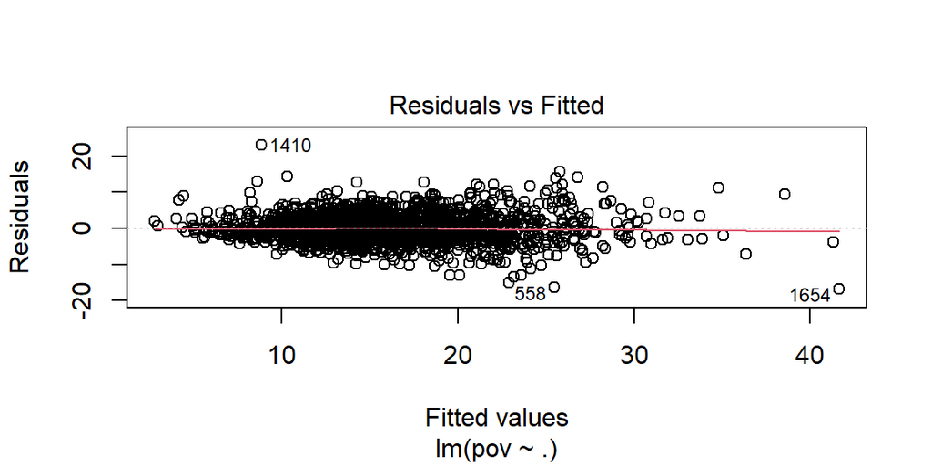

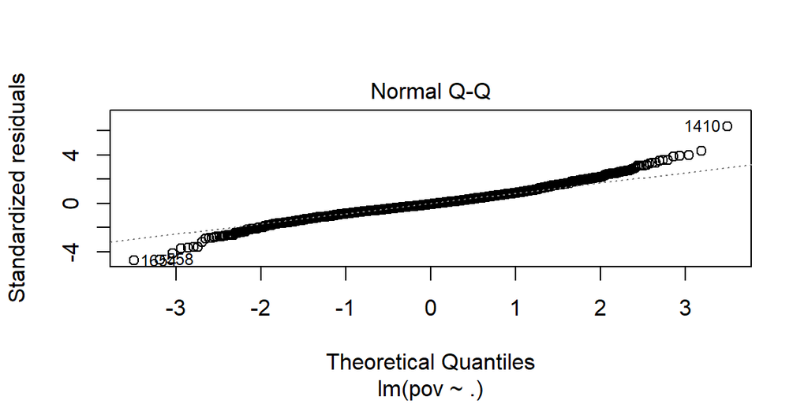

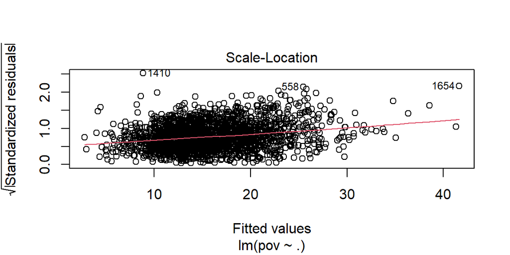

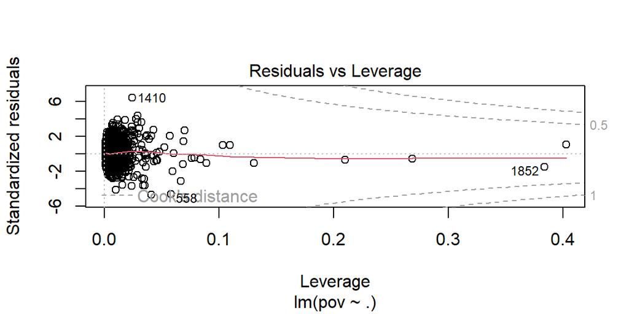

```r
plot(fit_pov)
```

# Crime Rate

## LASSO Selection

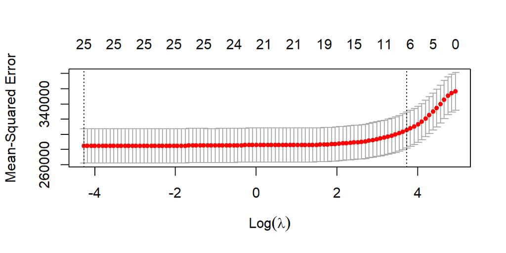

```r
crime_y <- data_train$crime_rate
crime_data <- inp_data
set.seed(SEED)
cv_res_crime <- cv.glmnet(as.matrix(crime_data), crime_y)
plot(cv_res_crime)
```

```r
crime_coefs <- coef(cv_res_crime, s = "lambda.1se")
crime_coefs <- crime_coefs[which(crime_coefs != 0),]

crime_coefs <- c("crime_rate", names(crime_coefs)[-1])
crime_data <- data[, ..crime_coefs]
```

## Linear Regression & Significance

Do basically the same thing as the previous 3 models.

```r
fit_crime <- lm(crime_rate ~ ., crime_data)
summary(fit_crime)
```

```
Call:
lm(formula = crime_rate ~ ., data = crime_data)

Residuals:
   Min     1Q Median     3Q    Max
 -1475   -335    -92    225   5453

Coefficients:
                      Estimate Std. Error t value          Pr(>|t|)
(Intercept)           -1663.60     348.58   -4.77 0.000001931685479 ***
hs_grad                  -1.55       2.95   -0.53            0.5991
bachelors                -4.86       1.71   -2.84            0.0045 **
black                    23.99       1.82   13.21           < 2e-16 ***
pac_isl                 367.04      51.02    7.19 0.000000000000842 ***
median_age               25.35       2.81    9.02           < 2e-16 ***
veterans                 38.97       5.14    7.58 0.000000000000049 ***
persons_per_household   377.09      58.98    6.39 0.000000000195974 ***
uninsured                13.26       2.91    4.56 0.000005358345658 ***
---
Signif. codes:  0 '***' 0.001 '**' 0.01 '*' 0.05 '.' 0.1 ' ' 1

Residual standard error: 533 on 2326 degrees of freedom
Multiple R-squared:  0.196, Adjusted R-squared:  0.193
F-statistic: 70.8 on 8 and 2326 DF,  p-value: <2e-16
```

```r
fit_crime <- lm(crime_rate ~ . - hs_grad, crime_data)
summary(fit_crime)
```

```
Call:
lm(formula = crime_rate ~ . - hs_grad, data = crime_data)

Residuals:
   Min     1Q Median     3Q    Max
 -1488   -334    -91    226   5452

Coefficients:
                      Estimate Std. Error t value Pr(>|t|)
(Intercept)           -1802.91     226.44   -7.96  2.6e-15 ***
bachelors                -5.43       1.34   -4.06  5.1e-05 ***
black                    24.19       1.77   13.63  < 2e-16 ***
pac_isl                 366.70      51.00    7.19  8.7e-13 ***
median_age               25.43       2.81    9.06  < 2e-16 ***
veterans                 37.96       4.77    7.96  2.6e-15 ***
persons_per_household   383.13      57.85    6.62  4.3e-11 ***
uninsured                13.92       2.62    5.31  1.2e-07 ***
---
Signif. codes:  0 '***' 0.001 '**' 0.01 '*' 0.05 '.' 0.1 ' ' 1

Residual standard error: 533 on 2327 degrees of freedom
Multiple R-squared:  0.196, Adjusted R-squared:  0.193
F-statistic: 80.9 on 7 and 2327 DF,  p-value: <2e-16
```

This time, it seems that just `hs_grad` isn’t significant.

```r
bad <- "hs_grad"
crime_data <- crime_data %>%
        select(-all_of(bad))

fit_crime <- lm(crime_rate ~ ., crime_data)
summary(fit_crime)
```

```
Call:
lm(formula = crime_rate ~ ., data = crime_data)

Residuals:
   Min     1Q Median     3Q    Max
 -1488   -334    -91    226   5452

Coefficients:
                      Estimate Std. Error t value Pr(>|t|)
(Intercept)           -1802.91     226.44   -7.96  2.6e-15 ***
bachelors                -5.43       1.34   -4.06  5.1e-05 ***
black                    24.19       1.77   13.63  < 2e-16 ***
pac_isl                 366.70      51.00    7.19  8.7e-13 ***
median_age               25.43       2.81    9.06  < 2e-16 ***
veterans                 37.96       4.77    7.96  2.6e-15 ***
persons_per_household   383.13      57.85    6.62  4.3e-11 ***
uninsured                13.92       2.62    5.31  1.2e-07 ***
---
Signif. codes:  0 '***' 0.001 '**' 0.01 '*' 0.05 '.' 0.1 ' ' 1

Residual standard error: 533 on 2327 degrees of freedom
Multiple R-squared:  0.196, Adjusted R-squared:  0.193
F-statistic: 80.9 on 7 and 2327 DF,  p-value: <2e-16
```

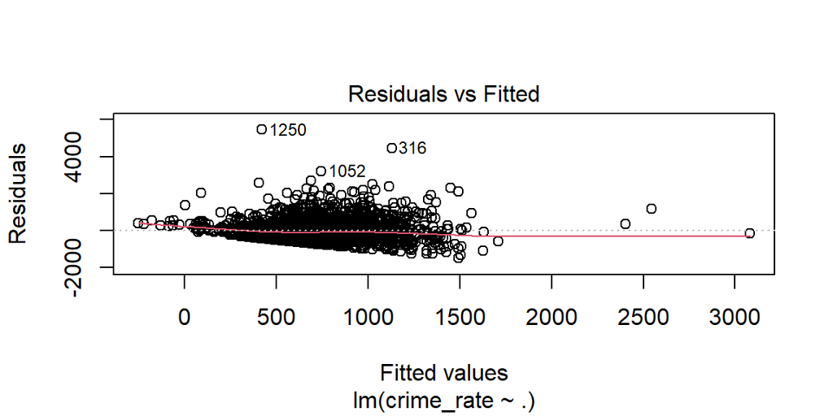

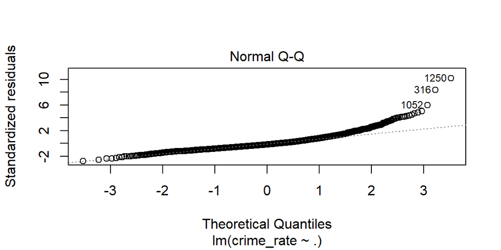

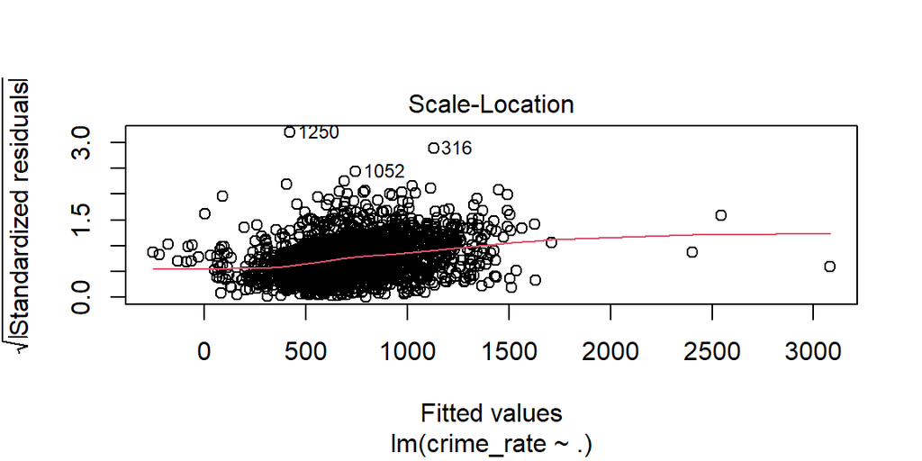

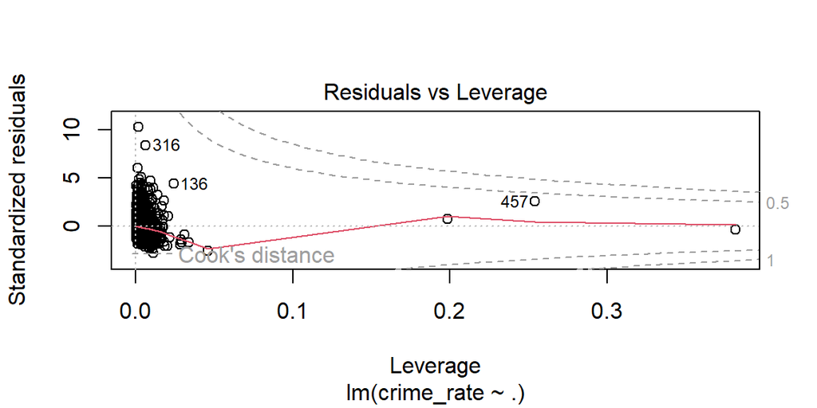

```r
plot(fit_crime)
```

# Deep Learning

Here, we set up some constants for the deep learning & split the training/testing data as well.

```r
EPOCHS <- 40
VAL_SPLIT <- .15
BATCH_SIZE <- 512

inp_data <- needed %>% select(-c('unemployment_rate', 'crime_rate', 'median_household_income', 'poverty'))
train_size <- floor(nrow(inp_data) * 0.7)
train_inds <- sample(nrow(inp_data), train_size)

train_X <- as.matrix(inp_data[train_inds,])
test_X <- as.matrix(inp_data[-train_inds,])
inp_len <- dim(train_X)[2]
```

## Unemployment

We’ll just make a model for unemployment to see how it goes.

```r
train_y <- needed$unemployment_rate[train_inds]
test_y <- needed$unemployment_rate[-train_inds]

ue_model <- keras_model_sequential() %>%
        layer_dense(units = 16, activation = "relu", input_shape = inp_len) %>%
        layer_dense(units = 8, activation = "relu") %>%
        layer_dense(units = 4, activation = "relu") %>%
        layer_dense(units = 3, activation = "relu") %>%
        layer_dense(units = 1)
```

```
Loaded Tensorflow version 2.9.1
```

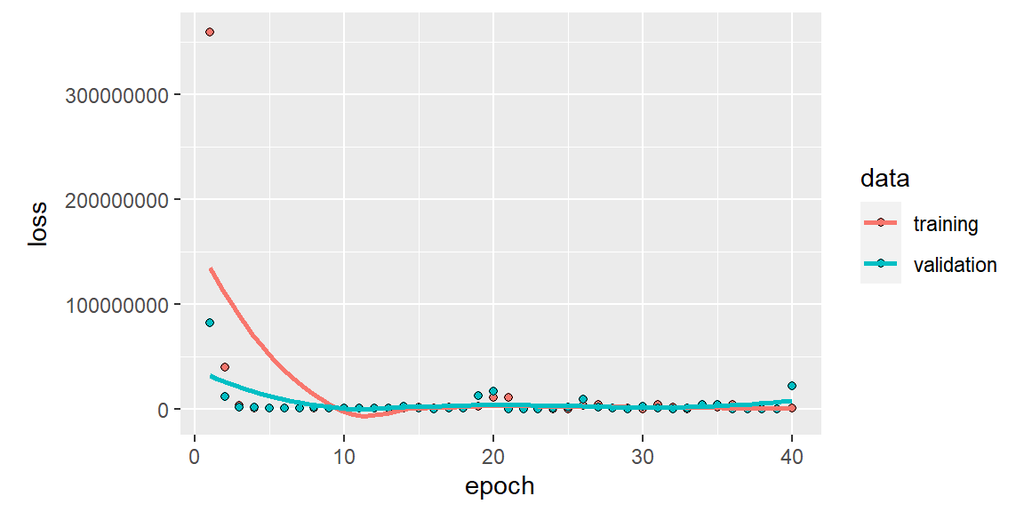

```r
ue_model %>% compile(
        optimizer = "rmsprop",
        loss = "mse"
)

ue_fit <- ue_model %>% fit(
        train_X, train_y,
        epochs = EPOCHS,
        validation_split = VAL_SPLIT,
        batch_size = BATCH_SIZE
)
plot(ue_fit)
```

```r
ue_model %>% evaluate(test_X, test_y)
```

```
    loss
53895868
```